# Reproducible Research: Peer Assessment 1

## Loading and preprocessing the data

Data loaded using read.csv after which it is filtered by removing NA rows. hist is used to plot a histogram

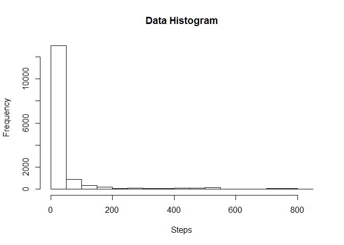

```r
data <- read.csv("activity.csv",colClasses = "character")
stepsVector  <- data$steps
filteredData <- data[!is.na(stepsVector),]

filteredData[, 1] <- as.numeric(filteredData[, 1])
filteredData[, 2] <- as.Date(filteredData[, 2],"%Y-%m-%d")

hist(filteredData$steps,xlab = "Steps", ylab = "Frequency", main = "Data Histogram")
```

## What is mean total number of steps taken per day?

Mean steps calculated using mean function and median calculated using median function

```r
meanSteps <- mean(filteredData$steps)
medianSteps <- median(filteredData$steps)
```

## What is the average daily activity pattern?

for this question, we will need to write a helper function to compute daily steps. The code is as follows

```r
calcTotalForDay <- function (reqDay,data) {
    dateVector <- data[, 2]
    dayData <- data[dateVector == reqDay,]

    d <- c(sum(dayData$steps),reqDay)

    d

}
```

Once the helper function is done, we can compute daily steps with the following code

```r
days <- unique(sort(filteredData[,2]))
dailyData <- sapply(days,calcTotalForDay,data = filteredData)

dailyData <- data.frame(t(dailyData))

cnames <- c("steps", "day")
colnames(dailyData) <- cnames

dailyData[, 1] <- as.numeric(as.character(dailyData[, 1]))
```

And then compute daily mean and median using

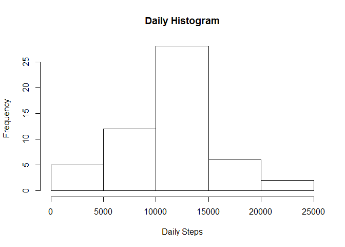

```r
hist(dailyData$steps,xlab = "Daily Steps", ylab = "Frequency", main = "Daily Histogram")
```

```r
totalDailySteps  <- dailyData$steps
meanDailySteps   <- mean(totalDailySteps)
medianDailySteps <- median(totalDailySteps)
```

The mean daily steps is 10766 The median daily steps is 10765

To compute the most active 5 minute interval, we need another helper function

```r
fiveMinsIntervalForDay <- function (reqDay,data) {
    dateVector <- data[, 2]
    dayData <- data[dateVector == reqDay,]

    d <- dayData$steps

    d

}
```

With this helper function, we can proceed. First we compute a table with all 5 minute interval accross all days and then name the columns

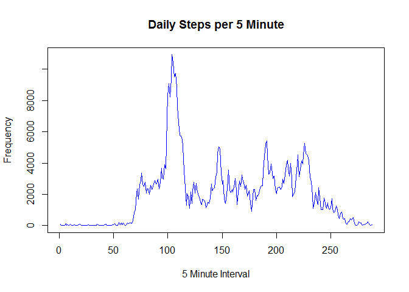

```r
dailyPer5MinsData <- sapply(days,fiveMinsIntervalForDay,data = filteredData)
dailyPer5MinsData <- data.frame(t(dailyPer5MinsData))
cnames <- (c(1:length(dailyPer5MinsData))-1)*5
cnames <- c(1:length(dailyPer5MinsData))-1
cnames <- as.character(cnames)
colnames(dailyPer5MinsData) <- cnames

per5MinuteSum <- colSums (dailyPer5MinsData)

#plot
plot(per5MinuteSum, type="l", col="blue",xlab = "5 Minute Interval", ylab = "Frequency", main = "Daily Steps per 5 Minute")
```

```r
# which 5 min interval is max
mostActive5Minute <- per5MinuteSum[per5MinuteSum == max(per5MinuteSum)]
```

The most active 5 minute interval is 510 (the 103rd 5 minute) reading and its value is 10927

## Imputing missing values

The total number of missing values is obtained with the code

```r
stepsVector  <- data$steps
numberOfNaRows <-nrow(data[is.na(stepsVector),])
```

The number of rows with missing data is 2304

To fill in missing data, I replaced NA values with the mean daily value divided by total number of readings (288) as follows

```r
dataWithFixedNa <- data
dataWithFixedNa$steps[is.na(dataWithFixedNa$steps)] = meanDailySteps/288
```

The original data with NA is the variable “data” and the updated data with average values replacing the NA values is the variable “dataWithFixedNa”.

Now I calculate new daily steps and store them is the variable “dataWithFixedNaDailyData”.

```r
# data with fixedNa to daily
days <- unique(sort(filteredData[,2]))
dataWithFixedNa[, 1] <- as.numeric(as.character(dataWithFixedNa[, 1]))
dataWithFixedNaDailyData <- sapply(days,calcTotalForDay,data = dataWithFixedNa)
dataWithFixedNaDailyData <- data.frame(t(dataWithFixedNaDailyData))
dataWithFixedNaDailyData[, 1] <- as.numeric(as.character(dataWithFixedNaDailyData[, 1]))

cnames <- c("steps", "day")
colnames(dataWithFixedNaDailyData) <- cnames
```

To plot the new histograms, I use

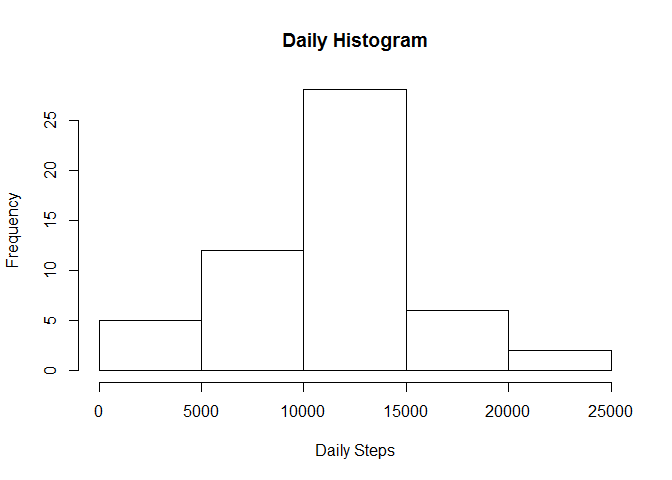

```r
hist(dataWithFixedNaDailyData$steps,xlab = "Daily Steps", ylab = "Frequency", main = "Daily Histogram")
```

## Are there differences in activity patterns between weekdays and weekends?

A helper function to help determine day type which will be called from sapply is defined as

```r
weekdayOrWeekend <- function (testDay) {
    if (grepl(testDay,c("Saturday")) | grepl(testDay,c("Sunday")) ) {
        d <- 0
    } else {
        d <- 1
    }
    d
}
```

After defining this function I created a vector containg all dates and pass that vector with the function “weekdayOrWeekend” to sapply and then append the result to “filteredData” using cbind.

```r
daysData <- filteredData$date
daysData <- as.Date(as.character(filteredData$date))
stepDays <- weekdays(daysData)
stepDaysBinom <- sapply(stepDays,weekdayOrWeekend)
stepDaysBinomFactor <- factor(stepDaysBinom, labels = c("weekend", "weekday"))
dailyDataWithWeekendOrWeekday <- cbind(filteredData, stepDaysBinomFactor)

cnames <- c("steps", "date", "interval", "day_type")
colnames(dailyDataWithWeekendOrWeekday) <- cnames
```

To create weekend and weekds plots I use a modified version of the helper function described earlier

```r
fiveMinsIntervalForWeekDayType <- function (reqDay,data,type) {
    dateVector <- data[, 2]
    daytypeVector <- data[, 4]

    dayData <- data[dateVector == reqDay & daytypeVector == type,]

    d <- NULL

    if (nrow(dayData)>0) {
        d <- dayData$steps
    } else {
        d <- as.numeric(rep(NA,288))
    }
    d
}
```

Then I run the following code

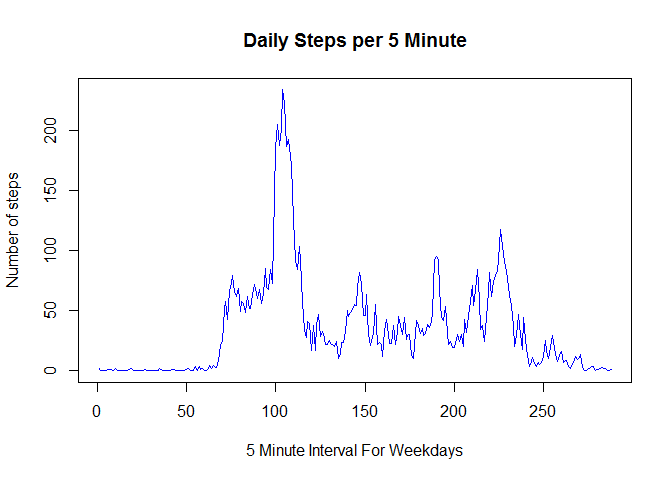

```r
# daily per 5 mins
days <- unique(sort(dailyDataWithWeekendOrWeekday$date))
dailyPer5MinsDataWeekDay <- sapply(days,fiveMinsIntervalForWeekDayType,data = dailyDataWithWeekendOrWeekday, type="weekday")
dailyPer5MinsDataWeekEnd <- sapply(days,fiveMinsIntervalForWeekDayType,data = dailyDataWithWeekendOrWeekday, type="weekend")
dailyPer5MinsDataWeekDay <- data.frame(t(dailyPer5MinsDataWeekDay))
dailyPer5MinsDataWeekEnd <- data.frame(t(dailyPer5MinsDataWeekEnd))

vecWeekday  <- dailyPer5MinsDataWeekDay[1]
vecWeekend  <- dailyPer5MinsDataWeekEnd[1]

dailyPer5MinsDataWeekDay <- dailyPer5MinsDataWeekDay[!is.na(vecWeekday),]
dailyPer5MinsDataWeekEnd <- dailyPer5MinsDataWeekEnd[!is.na(vecWeekend),]

cnames <- (c(1:length(dailyPer5MinsDataWeekDay))-1)*5
cnames <- as.character(cnames)
colnames(dailyPer5MinsDataWeekDay) <- cnames
dailyPer5MinsDataWeekDaySum <- colSums (dailyPer5MinsDataWeekDay)/nrow(dailyPer5MinsDataWeekDay)

cnames <- (c(1:length(dailyPer5MinsDataWeekEnd))-1)*5
cnames <- as.character(cnames)
colnames(dailyPer5MinsDataWeekEnd) <- cnames
dailyPer5MinsDataWeekEndSum <- colSums (dailyPer5MinsDataWeekEnd)/nrow(dailyPer5MinsDataWeekEnd)

#plot
plot(dailyPer5MinsDataWeekDaySum, type="l", col="blue",xlab = "5 Minute Interval For Weekdays", ylab = "Number of steps", main = "Daily Steps per 5 Minute")
```

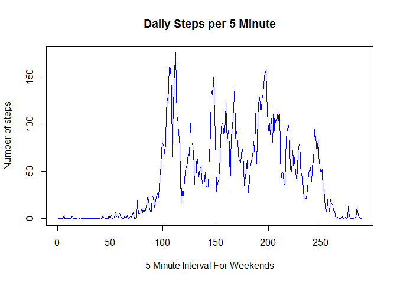

```r
plot(dailyPer5MinsDataWeekEndSum, type="l", col="blue",xlab = "5 Minute Interval For Weekends", ylab = "Number of steps", main = "Daily Steps per 5 Minute")
```